# Data Analysis

```python
import pandas as pd
import numpy as np
import matplotlib.pyplot as plt
import seaborn as sns
```

```python
boston_url = 'https://cf-courses-data.s3.us.cloud-object-storage.appdomain.cloud/IBMDeveloperSkillsNetwork-ST0151EN-SkillsNetwork/labs/boston_housing.csv'
boston_df=pd.read_csv(boston_url)
boston_df
```

|  | Unnamed: 0 | CRIM | ZN | INDUS | CHAS | NOX | RM | AGE | DIS | RAD | TAX | PTRATIO | LSTAT | MEDV |
| --- | --- | --- | --- | --- | --- | --- | --- | --- | --- | --- | --- | --- | --- | --- |
| 0 | 0 | 0.00632 | 18.0 | 2.31 | 0.0 | 0.538 | 6.575 | 65.2 | 4.0900 | 1.0 | 296.0 | 15.3 | 4.98 | 24.0 |
| 1 | 1 | 0.02731 | 0.0 | 7.07 | 0.0 | 0.469 | 6.421 | 78.9 | 4.9671 | 2.0 | 242.0 | 17.8 | 9.14 | 21.6 |
| 2 | 2 | 0.02729 | 0.0 | 7.07 | 0.0 | 0.469 | 7.185 | 61.1 | 4.9671 | 2.0 | 242.0 | 17.8 | 4.03 | 34.7 |
| 3 | 3 | 0.03237 | 0.0 | 2.18 | 0.0 | 0.458 | 6.998 | 45.8 | 6.0622 | 3.0 | 222.0 | 18.7 | 2.94 | 33.4 |
| 4 | 4 | 0.06905 | 0.0 | 2.18 | 0.0 | 0.458 | 7.147 | 54.2 | 6.0622 | 3.0 | 222.0 | 18.7 | 5.33 | 36.2 |
| ... | ... | ... | ... | ... | ... | ... | ... | ... | ... | ... | ... | ... | ... | ... |
| 501 | 501 | 0.06263 | 0.0 | 11.93 | 0.0 | 0.573 | 6.593 | 69.1 | 2.4786 | 1.0 | 273.0 | 21.0 | 9.67 | 22.4 |
| 502 | 502 | 0.04527 | 0.0 | 11.93 | 0.0 | 0.573 | 6.120 | 76.7 | 2.2875 | 1.0 | 273.0 | 21.0 | 9.08 | 20.6 |
| 503 | 503 | 0.06076 | 0.0 | 11.93 | 0.0 | 0.573 | 6.976 | 91.0 | 2.1675 | 1.0 | 273.0 | 21.0 | 5.64 | 23.9 |
| 504 | 504 | 0.10959 | 0.0 | 11.93 | 0.0 | 0.573 | 6.794 | 89.3 | 2.3889 | 1.0 | 273.0 | 21.0 | 6.48 | 22.0 |
| 505 | 505 | 0.04741 | 0.0 | 11.93 | 0.0 | 0.573 | 6.030 | 80.8 | 2.5050 | 1.0 | 273.0 | 21.0 | 7.88 | 11.9 |

506 rows × 14 columns

```python
boston_df.shape
```

```
(506, 14)
```

The following describes the dataset variables:

· CRIM - per capita crime rate by town

· ZN - proportion of residential land zoned for lots over 25,000 sq.ft.

· INDUS - proportion of non-retail business acres per town.

· CHAS - Charles River dummy variable (1 if tract bounds river; 0 otherwise)

· NOX - nitric oxides concentration (parts per 10 million)

· RM - average number of rooms per dwelling

· AGE - proportion of owner-occupied units built prior to 1940

· DIS - weighted distances to five Boston employment centres

· RAD - index of accessibility to radial highways

· TAX - full-value property-tax rate per $10,000

· PTRATIO - pupil-teacher ratio by town

· LSTAT - % lower status of the population

· MEDV - Median value of owner-occupied homes in $1000's

For all visualizations, please include a title in each graph and appropriate labels

Generate the following and explain your findings:

For the "Median value of owner-occupied homes" provide a boxplot

Provide a bar plot for the Charles river variable

Provide a boxplot for the MEDV variable vs the AGE variable. (Discretize the age variable into three groups of 35 years and younger, between 35 and 70 years and 70 years and older)

Provide a scatter plot to show the relationship between Nitric oxide concentrations and the proportion of non-retail business acres per town. What can you say about the relationship?

Create a histogram for the pupil to teacher ratio variable

```python
boston_df['MEDV']
```

```
0      24.0
1      21.6
2      34.7
3      33.4
4      36.2
       ...
501    22.4
502    20.6
503    23.9
504    22.0
505    11.9
Name: MEDV, Length: 506, dtype: float64
```

### 1. For the "Median value of owner-occupied homes" provide a boxplot

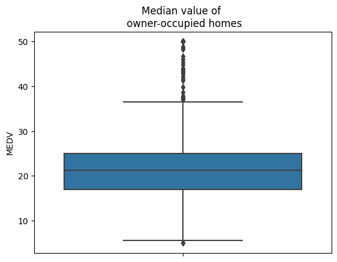

```python
a = sns.boxplot(y=boston_df['MEDV'])
a.set_title("Median value of \n owner-occupied homes")
plt.show()
```

### 2. Provide a bar plot for the Charles river variable

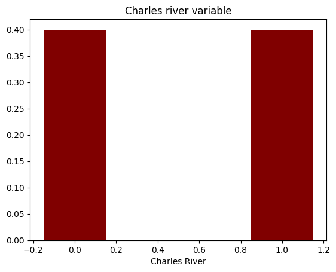

```python
#fig = plt.figure(figsize = (8,4))
y = boston_df['CHAS']
plt.bar(y,  color ='maroon',height=0.4,
        width = 0.3)
plt.xlabel("Charles River")
plt.title('Charles river variable')
plt.show()
```

#### 3. Provide a boxplot for the MEDV variable vs the AGE variable.

(Discretize the age variable into three groups of 35 years and younger, between 35 and 70 years and 70 years and older)

```python
boston_df.loc[(boston_df['AGE'] <= 35), 'Age_Group'] = '35 years and younger'
boston_df.loc[(boston_df['AGE'] > 35) & (boston_df['AGE'] < 70), 'Age_Group'] = 'between 35 and 70 years'
boston_df.loc[(boston_df['AGE'] >= 70), 'Age_Group'] = '70 years and older'
```

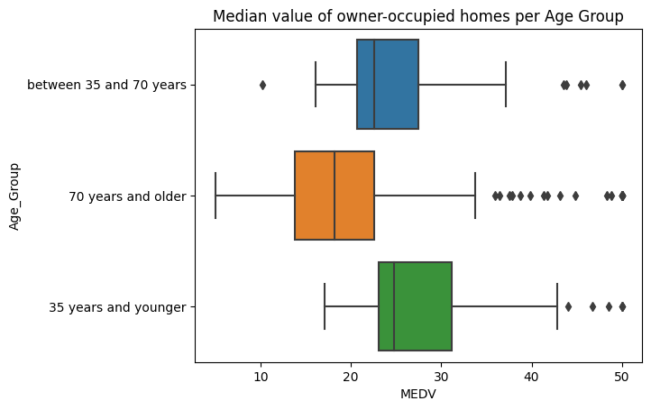

```python
ax1 = sns.boxplot(x = 'MEDV', y = 'Age_Group', data = boston_df)
ax1.set_title('Median value of owner-occupied homes per Age Group')
```

### 4. Provide a scatter plot to show the relationship between Nitric oxide concentrations and the proportion of non-retail business acres per town. What can you say about the relationship?

```python
boston_df.columns
```

```
Index(['Unnamed: 0', 'CRIM', 'ZN', 'INDUS', 'CHAS', 'NOX', 'RM', 'AGE', 'DIS',
       'RAD', 'TAX', 'PTRATIO', 'LSTAT', 'MEDV', 'Age_Group'],
      dtype='object')
```

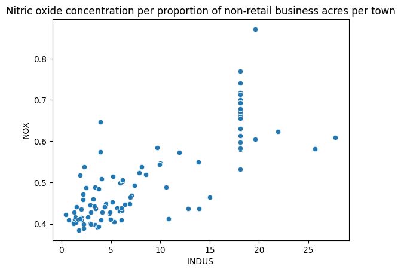

```python
ax3 = sns.scatterplot(y = boston_df['NOX'], x = boston_df['INDUS'])
ax3.set_title('Nitric oxide concentration per proportion of non-retail business acres per town')
```

1. There is a strong relationship betwwen low Nitric Oxide concentration and low proportion of non-retail business acres per town.
2. Higher the proportion of non-retail business acres per town, higher is the concentration of Nitric Oxide.

### 5. Create a histogram for the pupil to teacher ratio variable

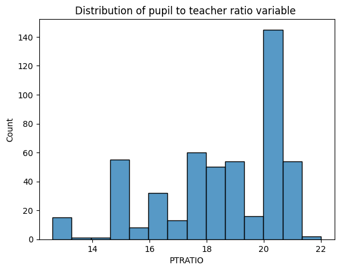

```python
s1 = sns.histplot(data = boston_df, x=boston_df['PTRATIO'])
s1.set_title('Distribution of pupil to teacher ratio variable ')
```

### Task 5

### 1.Is there a significant difference in median value of houses bounded by the Charles river or not? (T-test for independent samples)

Hypothesis:

Null Hypothesis - There is no significant difference in median value between houses bounded and not bounded by the Charles River

Alternative Hypothesis - There is a significant difference in median value between houses bounded and not bounded by the Charles River

```python
boston_df.loc[(boston_df['CHAS'] == 0), 'CHAS_new'] = 'FAR ' #far away from the river
boston_df.loc[(boston_df['CHAS'] == 1), 'CHAS_new'] = 'NEAR'# near the river
boston_df.head(5)
```

|  | Unnamed: 0 | CRIM | ZN | INDUS | CHAS | NOX | RM | AGE | DIS | RAD | TAX | PTRATIO | LSTAT | MEDV | Age_Group | CHAS_new |
| --- | --- | --- | --- | --- | --- | --- | --- | --- | --- | --- | --- | --- | --- | --- | --- | --- |
| 0 | 0 | 0.00632 | 18.0 | 2.31 | 0.0 | 0.538 | 6.575 | 65.2 | 4.0900 | 1.0 | 296.0 | 15.3 | 4.98 | 24.0 | between 35 and 70 years | FAR |
| 1 | 1 | 0.02731 | 0.0 | 7.07 | 0.0 | 0.469 | 6.421 | 78.9 | 4.9671 | 2.0 | 242.0 | 17.8 | 9.14 | 21.6 | 70 years and older | FAR |
| 2 | 2 | 0.02729 | 0.0 | 7.07 | 0.0 | 0.469 | 7.185 | 61.1 | 4.9671 | 2.0 | 242.0 | 17.8 | 4.03 | 34.7 | between 35 and 70 years | FAR |
| 3 | 3 | 0.03237 | 0.0 | 2.18 | 0.0 | 0.458 | 6.998 | 45.8 | 6.0622 | 3.0 | 222.0 | 18.7 | 2.94 | 33.4 | between 35 and 70 years | FAR |
| 4 | 4 | 0.06905 | 0.0 | 2.18 | 0.0 | 0.458 | 7.147 | 54.2 | 6.0622 | 3.0 | 222.0 | 18.7 | 5.33 | 36.2 | between 35 and 70 years | FAR |

```python
import scipy.stats
```

```python
scipy.stats.ttest_ind(boston_df[boston_df['CHAS_new'] == 'FAR']['MEDV'],
                      boston_df[boston_df['CHAS_new'] == 'NEAR']['MEDV'], equal_var = True)
```

[output not shown]

Hypothesis

Null Hypotesis: There is no statistical difference in Median values of houses (MEDV) for each proportion of owner occpied units built prior to 1940

Alternative Hypothesis: There is statistical difference in Median values of houses (MEDV) for each proportion of owner occpied units built prior to 1940

```python
! python -m pip install statsmodels
```

```python
! python -m pip install statsmodels
from statsmodels.formula.api import ols
lm = ols('MEDV ~ AGE', data = boston_df).fit()
table = sm.stats.anova_lm(lm)
print(table)
```

[output not shown]

### 3. Can we conclude that there is no relationship between Nitric oxide concentrations and proportion of non-retail business acres per town? (Pearson Correlation)

Null Hypothesis: Nitric Oxide concentration is not correlated with the proportion of non-retail business acres per town

Alternative Hypothesis: Nitric Oxide concentration is correlated with the proportion of non-retail business acres per town

```python
scipy.stats.pearsonr(boston_df['NOX'], boston_df['INDUS'])
```

```
PearsonRResult(statistic=0.7636514469209157, pvalue=7.913361061233745e-98)
```

Pearson Coefficient is 0.76365 and p-value is less tha 0.05.So, we reject the null nypothesis. so, we can conclude that, Nitric Oxide concentration is correlated with the proportion of non-retail business acres per town

```python
! python -m pip install statsmodels
import statsmodels.api as sm
x = boston_df['DIS']
y = boston_df['MEDV']

x = statsmodels.add_constant(x)

model = statsmodels.OLS(y, x).fit()
predisction = model.predict(x)

model.summary()
```

[output not shown]